# Assignment 1

Loading and preprocessing data

```r
library(reshape2)
library(lattice)
if(!file.exists("./data")){dir.create("./data")}

activity <- read.csv("./data/activity.csv")
```

Processing and transforming the dataset by changing the date variable to type “date”

```r
activity$date=as.Date(activity$date)
```

What is mean total number of steps taken per day?

1. Calculating and reporting the total number of steps per day by using the melt and dcast functions

```r
activity_melt=melt(activity, id=c("date"), measure.vars=c("steps"))
activityMeltCastSum=dcast(activity_melt, date~variable, sum)
```

Histogram showing the number of distribution of the total number of steps per day

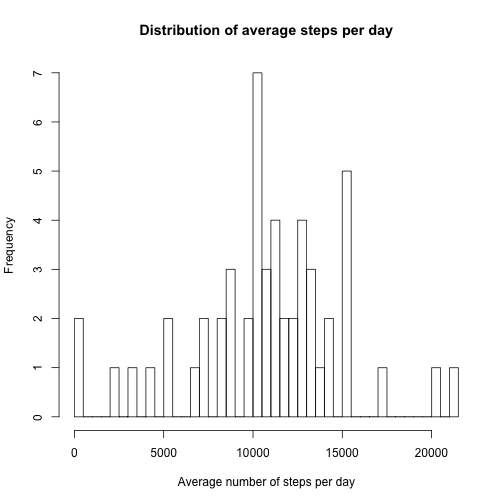

```r
hist(activityMeltCastSum[,2], breaks=50, xlab="Average number of steps per day", main="Distribution of average steps per day")
```

1. Calculating the average number of steps per day by using the melt and dcast functions and reporting the average number of steps per day by using the summary functiion

```r
activityMeltCastMean=dcast(activity_melt, date~variable, mean)
summary(activityMeltCastMean)
```

```
##       date                steps
##  Min.   :2012-10-01   Min.   : 0.14
##  1st Qu.:2012-10-16   1st Qu.:30.70
##  Median :2012-10-31   Median :37.38
##  Mean   :2012-10-31   Mean   :37.38
##  3rd Qu.:2012-11-15   3rd Qu.:46.16
##  Max.   :2012-11-30   Max.   :73.59
##                       NA's   :8
```

```r
activityMeltCastMean
```

```
##          date   steps
## 1  2012-10-01      NA
## 2  2012-10-02  0.4375
## 3  2012-10-03 39.4167
## 4  2012-10-04 42.0694
## 5  2012-10-05 46.1597
## 6  2012-10-06 53.5417
## 7  2012-10-07 38.2465
## 8  2012-10-08      NA
## 9  2012-10-09 44.4826
## 10 2012-10-10 34.3750
## 11 2012-10-11 35.7778
## 12 2012-10-12 60.3542
## 13 2012-10-13 43.1458
## 14 2012-10-14 52.4236
```

[output cut: 47 more lines]

```r
activityMeltCastMedian=dcast(activity_melt, date~variable, median, fill=NaN)
activityMeltCastMedian
```

```
##          date steps
## 1  2012-10-01    NA
## 2  2012-10-02     0
## 3  2012-10-03     0
## 4  2012-10-04     0
## 5  2012-10-05     0
## 6  2012-10-06     0
## 7  2012-10-07     0
## 8  2012-10-08    NA
## 9  2012-10-09     0
## 10 2012-10-10     0
## 11 2012-10-11     0
## 12 2012-10-12     0
## 13 2012-10-13     0
## 14 2012-10-14     0
```

[output cut: 47 more lines]

What is the average daily activity pattern?

1. Calculating and reporting the mean number of steps per interval

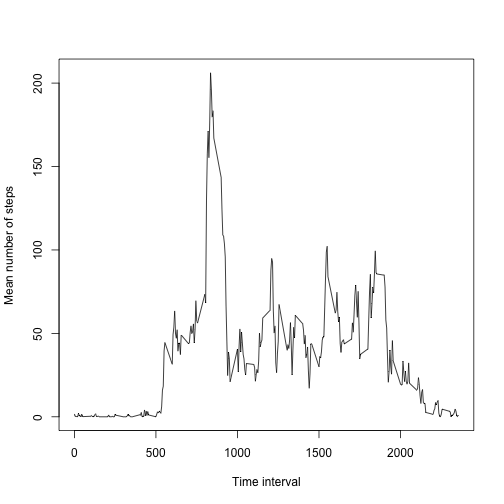

```r
activityMeltInterval=melt(activity, id=c("interval"), measure.vars=c("steps"))
activityMeltCastIntervalMean=dcast(activityMeltInterval, interval~variable, mean, na.rm=TRUE)


plot(activityMeltCastIntervalMean$interval, activityMeltCastIntervalMean$steps,type="l", xlab="Time interval", ylab="Mean number of steps")
```

1. Finding the interval with the max value by using the which.max function. The intervak with the max value is:

```r
activityMeltCastIntervalMean[which.max(activityMeltCastIntervalMean $steps), 1]
```

```
## [1] 835
```

Imputing missing values

1. Finding the total number of missing values by reinterating through all the rows in the dataset and checking the missing values in all the three variables

```r
count=0
for (i in 1:nrow(activity)){
  if (is.na(activity[i,]$steps) | is.na(activity[i,]$date) | is.na(activity[i,]$interval)) {
        count=count+1
    }
}
sum(!complete.cases(activity))
```

```
## [1] 2304
```

1. Imputing the missing values in the dataset by using the mean values for each interval.

```r
activityImputed=activity
for (i in 1:nrow(activityImputed)){
    if (is.na(activityImputed[i,]$steps)) {
        rowNumb=which(activityMeltCastIntervalMean$interval==activity[i,]$interval)
        activityImputed[i,]$steps= activityMeltCastIntervalMean[rowNumb,]$steps
    }
}
```

1. activityImputed is the new dataset containing the imputed values
2. Calculating the mean and median per day for the Imputed values

```r
activityImputedMelt=melt(activityImputed, id=c("date"), measure.vars=c("steps"))
activityImputedMeltCastSum=dcast(activityImputedMelt, date~variable, sum)
```

Histogram showing the number of distribution of the total number of steps per day

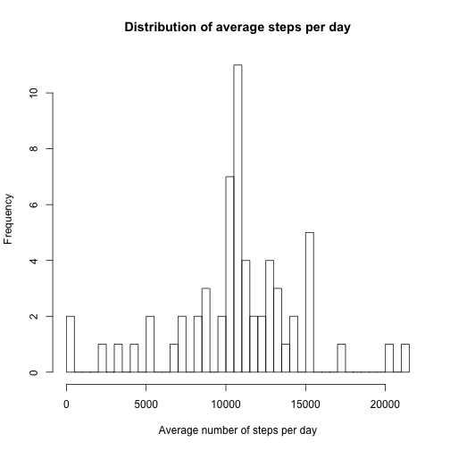

```r
hist(activityImputedMeltCastSum[,2], breaks=50, xlab="Average number of steps per day", main="Distribution of average steps per day")
```

Table reporting the average number of steps per day for Activity datase with the Imputed values

```r
activityImputedMeltCastMean=dcast(activityImputedMelt, date~variable, mean)
activityImputedMeltCastMean
```

```
##          date   steps
## 1  2012-10-01 37.3826
## 2  2012-10-02  0.4375
## 3  2012-10-03 39.4167
## 4  2012-10-04 42.0694
## 5  2012-10-05 46.1597
## 6  2012-10-06 53.5417
## 7  2012-10-07 38.2465
## 8  2012-10-08 37.3826
## 9  2012-10-09 44.4826
## 10 2012-10-10 34.3750
## 11 2012-10-11 35.7778
## 12 2012-10-12 60.3542
## 13 2012-10-13 43.1458
## 14 2012-10-14 52.4236
```

[output cut: 47 more lines]

Table reporting the median number of steps per day

```r
activityImputedMeltCastMedian=dcast(activityImputedMelt, date~variable, median, fill=NaN)
activityImputedMeltCastMedian
```

```
##          date steps
## 1  2012-10-01 34.11
## 2  2012-10-02  0.00
## 3  2012-10-03  0.00
## 4  2012-10-04  0.00
## 5  2012-10-05  0.00
## 6  2012-10-06  0.00
## 7  2012-10-07  0.00
## 8  2012-10-08 34.11
## 9  2012-10-09  0.00
## 10 2012-10-10  0.00
## 11 2012-10-11  0.00
## 12 2012-10-12  0.00
## 13 2012-10-13  0.00
## 14 2012-10-14  0.00
```

[output cut: 47 more lines]

Are there differences in activity patterns between weekdays and weekends?

1. Creating a new factor variable weekdays which holds vaules either “weekday” or “weekend”

```r
activityImputed$weekdays=weekdays(activityImputed$date)

weekdays=NULL
for (i in 1:nrow(activityImputed)){
    if ((activityImputed[i,]$weekdays=="Saturday") || (activityImputed[i,]$weekdays=="Sunday")) {
        weekdays=c(weekdays,"weekend")
    } else{
        weekdays=c(weekdays,"weekday")
    }
}
activityImputed$weekdays=as.factor(weekdays)
```

1. Make a panel plot containing a time series plot (i.e. type = “l”) of the 5-minute interval (x-axis)

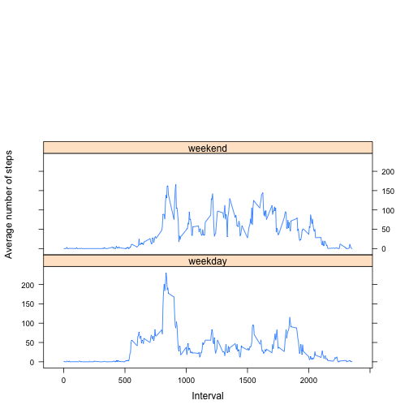

```r
activityImputedMelt=melt(activityImputed, id=c("interval", "weekdays"), measure.vars=c("steps"))
activityImputedMeltCastMean=dcast(activityImputedMelt, interval+weekdays~variable, mean)

xyplot(steps~interval|weekdays, activityImputedMeltCastMean, xlab="Interval", ylab="Average number of steps", layout=c(1,3), type="l")
```

The plot shows that the average number of steps during the weekend is higher compared to the average number of steps during the weekday.